**Winner, Winner, Chicken Dinner**

Playerunknown’s Battle Grounds (PUBG) is an online multiplayer battle royal game developed and published by PUBG Corporation, a subsidiary of South Korean video game company Bluehole. The game is based on previous mods that were created for other games using the film Battle Royal for inspiration and expanded into a standalone game. The premise of the game is simple: each game consists of a maximum of 100 players. There are different game modes: solo, duo’s or squads; we are going to be focusing on solo multiplayer game play. With each solo match, the objective is land on the map, collect weapons, armor, medical supplies and kill all opposing players and be the last man standing; obtaining a “chicken dinner” as the winner.

The game was first released for Microsoft Windows via Steam’s early access beta program in March 2017, with a full release on December 20, 2017. The same month, the game was released by Microsoft Studios for the Xbox One via its Xbox Game Preview program, and officially released in September 2018.

In this tutorial, our goal is to tidy the in-game data from “kylegame” and "PUBG_Player_Statistics" and provide insight into which weapons are used by the top 10, 5, 1 players of 10 games. In addition, we will attempt to correlate this data with a linear regression of kill-death ratio and win-ratio.

```python
#Getting Started with he Data
#We make use of Python 3 along with a few imported libraries: zlib, BeautifulSoup, matplotlib, pandas and more.

import re
import time
import json
import requests
import zlib
from bs4 import BeautifulSoup
import pandas as pd
import urllib.parse as urllib
import statsmodels.formula.api as smf
from sklearn.linear_model import LinearRegression
import matplotlib.pyplot as plt
import matplotlib
import seaborn as sns
import re

# The two datasets we will be using are found “kylegame” and "PUBG_Player_Statistics" mentioned earlier. Each dataset comes in
# the form of a CSV (Comma Separated Value) file.
```

**Preprocessing the Data**

Before running the code to read in the Objective file, we had to preprocess the data using Excel and any text editor. The Objectives dataset was huge, so to have a more manageably sized data frame we grabbed the first 10 games on the “Miramar” map.

```python
#Reading the Data

matplotlib.style.use('ggplot')
#from google.colab import files
#uploaded = files.upload()
test = pd.read_csv('kylegame.csv',sep = "|")
test.sort_values(["match_id","killer_placement"],inplace = True,ascending = True)
bar10  = test.loc[test["killer_placement"] <= 10]
unique10 = bar10["killed_by"].unique()
bar5  = test.loc[test["killer_placement"] <= 5]
unique5 = bar5["killed_by"].unique()
bar1  = test.loc[test["killer_placement"] <= 1]
unique1 = bar1["killed_by"].unique()
bar1count = bar1["killed_by"].nunique()
result10 = bar10.groupby('killed_by').size().reset_index()

unique_values10 = list(result10)
counting_values10 = result10.iloc[0]
```

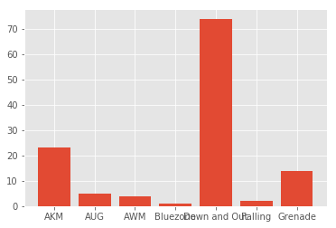

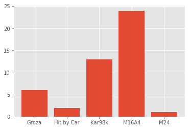

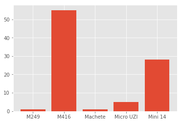

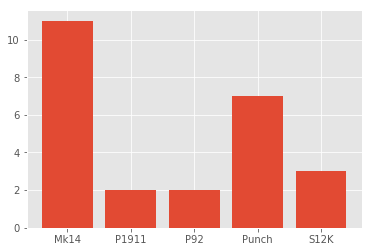

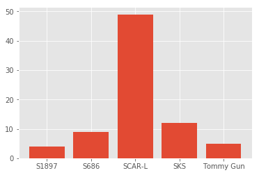

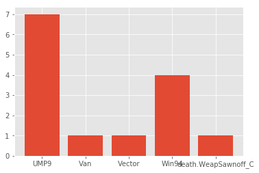

```python
# Tidying and Modifying the Data

plt.bar(x = result10.iloc[:7,0], height = result10.iloc[:7,1])
plt.show()
plt.bar(x = result10.iloc[7:12,0], height = result10.iloc[7:12,1])
plt.show()
plt.bar(x = result10.iloc[12:17,0], height = result10.iloc[12:17,1])
plt.show()
plt.bar(x = result10.iloc[17:22,0], height = result10.iloc[17:22,1])
plt.show()
plt.bar(x = result10.iloc[22:27,0], height = result10.iloc[22:27,1])
plt.show()
plt.bar(x = result10.iloc[27:32,0], height = result10.iloc[27:32,1])
plt.show()

# Here are bar graphs displaying the weapons used by the top 10 players of the selected 10 games
```

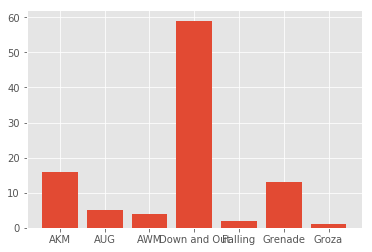

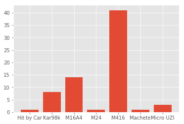

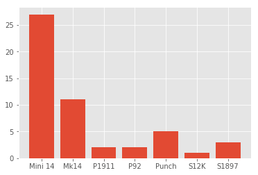

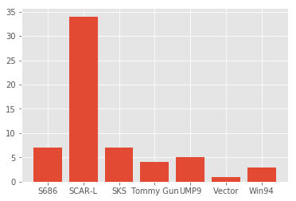

```python
# Tidying and Modifying the Data

result5 = bar5.groupby("killed_by").size().reset_index()
plt.bar(x = result5.iloc[:7,0], height = result5.iloc[:7,1])
plt.show()
plt.bar(x = result5.iloc[7:14,0], height = result5.iloc[7:14,1])
plt.show()
plt.bar(x = result5.iloc[14:21,0], height = result5.iloc[14:21,1])
plt.show()
plt.bar(x = result5.iloc[21:,0], height = result5.iloc[21:,1])
plt.show()

# Here are bar graphs displaying the weapons used by the top 5 players of the selected 10 games
```